# act_report

### Analysis and Visualization Report

#### Important Note: I could not submit on deadline due to the workspace outage problem, as I had all the files on the workspace servers. And after that, I found out it has reverted to an earlier checkpoint, hence I had to redo a big chunk of my work. Thank you for your understanding!

First we got statistical description for the tweet_master dataframe.

Then I did some visualizations to gain insights from the dataset.

#### Ratings distribution

```python
# Summary statistics of numerical values in Tweet_master df
```

|  | prediction_confidence | rating/10 | img_num | retweet_count | favorite_count |
| --- | --- | --- | --- | --- | --- |
| count | 1472.000000 | 1448.000000 | 1472.000000 | 1472.000000 | 1472.000000 |
| mean | 0.615564 | 10.956537 | 1.211957 | 2823.365489 | 9385.453125 |
| std | 0.260249 | 1.783639 | 0.572346 | 4803.640602 | 12678.228962 |
| min | 0.044333 | 2.000000 | 1.000000 | 16.000000 | 81.000000 |
| 25% | 0.393131 | 10.000000 | 1.000000 | 661.000000 | 2243.750000 |
| 50% | 0.616923 | 11.000000 | 1.000000 | 1460.500000 | 4578.000000 |
| 75% | 0.853770 | 12.000000 | 1.000000 | 3288.750000 | 11901.000000 |
| max | 0.999956 | 34.285714 | 4.000000 | 79515.000000 | 132810.000000 |

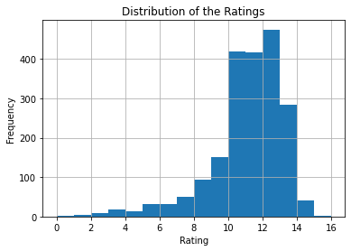

```python
# Rating Distribution
```

#### Insight(1): Most of the ratings lie between 10 and 14. mean rating is 10.96, which is above the denominator (10), but it is okay as the WeRateDogs scale is unique to them and has numbers over 10. there are some outliers, but most of the ratings are less than 15.

#### Most common dog breeds on WeRateDogs

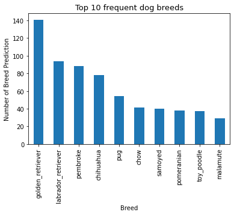

#### insight(2): Golden retriever is the most common dog breed on WeRateDogs. and then labrador retriever, pembroke and chihuahua are close to each other.

#### Correlation matrix between numerical variables in the master df

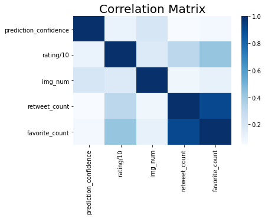

#### Insight (3) There is a strong correlation between favourite count and retweet count (~0.8)

#### Insight (4) There is a moderate correlation between rating and favourite and retweet count (~0.4)

### Boxplot diagram to illustrate the relation between the dog stages and ratings. the figure is shown in the rating range (7-14) so that the relation is shown clearly.

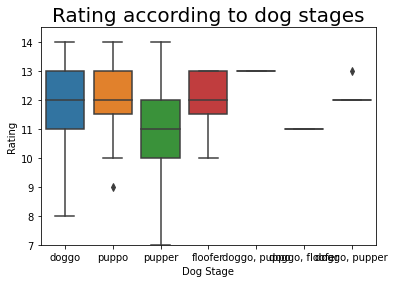

#### insight(5): puppos and floofer have similar rating distribution, but floofers have no ratings above 13. They share nearly the same median with the doggos, but doggos have a greater variability in ratings.

#### insight(6): puppers have lower ratings than the rest (on average)

### Tweet sources

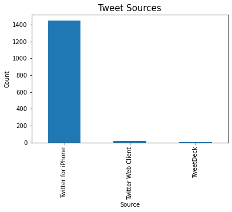

#### Insight (7): The most common tweet source is Twitter for iPhone.

### References:

https://cran.r-project.org/web/packages/tidyr/vignettes/tidy-data.html

https://stackoverflow.com/questions/51782443/np-where-do-nothing-if-condition-fails

https://stackoverflow.com/questions/52782024/reading-dictionary-stored-on-text-file-and-convert-to-pandas-dataframe

https://stackoverflow.com/questions/48140858/json-decoder-jsondecodeerror-extra-data-line-2-column-1-char-190

https://stackoverflow.com/questions/50585275/can-i-join-urls-using-os-path-join-in-python-or-is-there-a-better-way

https://stackoverflow.com/questions/2665866/what-does-wb-mean-in-this-code-using-python

https://nfpdiscussions.udacity.com/t/no-able-to-remove-duplicates-after-using-melt/83176

https://nfpdiscussions.udacity.com/t/data-wrangling-gathering/81672/2

https://nfpdiscussions.udacity.com/t/how-to-read-attribute-in-the-second-level-of-json-fil/82660/3

https://nfpdiscussions.udacity.com/t/im-stuck-in-project-2/41973/5

https://nfpdiscussions.udacity.com/t/pd-melt-inquiry/23200/4

https://stackoverflow.com/questions/12096252/use-a-list-of-values-to-select-rows-from-a-pandas-dataframe

https://stackoverflow.com/questions/18039057/python-pandas-error-tokenizing-data

https://github.com/sanjeevai/Wrangle_and_Analyze_data/blob/master/wrangle_act.ipynb

https://verascity.github.io/wrangle_data.html

https://stackoverflow.com/questions/19377969/combine-two-columns-of-text-in-pandas-dataframe

https://stackoverflow.com/questions/19482970/get-list-from-pandas-dataframe-column-headers

https://en.wikipedia.org/wiki/WeRateDogs

https://stackoverflow.com/questions/45184549/python-pandas-new-columns-value-if-the-item-is-in-the-list

https://github.com/bromero26/we-rate-dogs

https://pandas.pydata.org/pandas-docs/version/0.23.4/generated/pandas.DataFrame.melt.html#pandas.DataFrame.melt

https://github.com/StefaniePowazny/Wrangle-and-Analyze-Data/blob/master/wrangle_act.ipynb